# Homework 2: R programming - Question 2

Viviana Alejandra Rodriguez Romero

September 27, 2017

## Question 2

Install UsingR package. https://cran.r-project.org/web/packages/UsingR/index.html

- Explore its content, select any dataset you find interesting to explore and visualize
- Perform Exploratory Data Analysis (EDA) on it. Examples what to describe and comment on include:
  - Check the dimensions
  - Check classes of variables in rows and columns
  - Check summary statistics for rows/columns
  - Summarize and describe categorical values, if any
  - Display rows/columns as a table sorted by min/max value. Hint: Use **DT::datatable**
  - Visualized boxplots of rows/columns, where appropriate. Plot data on different scales on separate boxplots
  - Visualize data using histograms and/or density plots, if relevant
  - Make any other dataset-specific plots, e.g., plotting one variable vs. the other, performing linear regression on it
  - Comment on your exploration of the data

```r
library(UsingR)
library(DT)
library(ggplot2)
library(gridExtra)
```

It is believed that using cell phones while driving affects the driver’s attention, decreasing the reaction time to external events. The **reaction.time** dataset has simulated data of an experiment to assess the response time to an external event in two experimental groups. The first group assumed that the drivers were using cell phones while driving, whereas in the control group, drivers did not use cell phones.

```r
data(reaction.time)
ncol(reaction.time) #number of variables
```

```
## [1] 4
```

```r
nrow(reaction.time) #number of subjects
```

```
## [1] 60
```

```r
table(reaction.time$control) #Subjects per group
```

```
##
##  C  T
## 20 40
```

```r
datatable(reaction.time, options = list(order = list(list(4, 'desc'))),
          colnames = c('Age', 'Sex', 'Group', 'Time'),
          caption = 'Table 1: Raw data sorted by reaction time')
```

|  | Age | Sex | Group | Time |
| --- | --- | --- | --- | --- |
| 1 | 16-24 | F | T | 1.36007516082989 |
| 2 | 16-24 | M | T | 1.46793926451497 |
| 3 | 16-24 | M | T | 1.51203577079852 |
| 4 | 16-24 | F | T | 1.39064698511248 |
| 5 | 16-24 | M | T | 1.38420796553537 |
| 6 | 16-24 | M | C | 1.39387514659079 |
| 7 | 16-24 | M | T | 1.4190429016653 |
| 8 | 16-24 | F | T | 1.46118691161318 |
| 9 | 16-24 | F | T | 1.38246093101882 |
| 10 | 16-24 | M | C | 1.26015181574544 |

[output cut: 50 more lines]

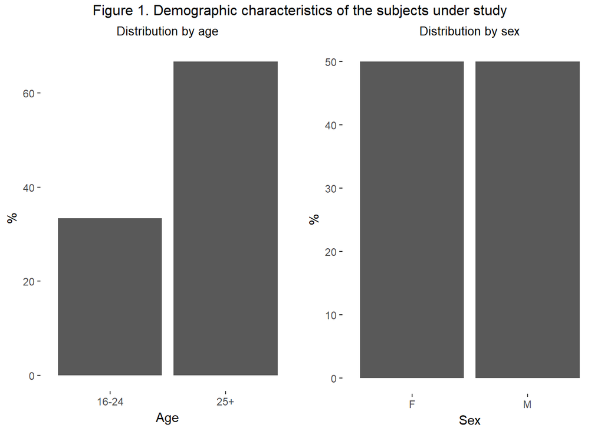

```r
p1<-ggplot(data=reaction.time, aes(x=age)) + geom_bar(aes(y = 100*(..count..)/sum(..count..))) +
  xlab("Age") + ylab("%") +  theme(panel.background = element_blank(), plot.title = element_text(size=10, hjust = 0.5)) +
  ggtitle("Distribution by age")
p2<-ggplot(data=reaction.time, aes(x=gender)) + geom_bar(aes(y = 100*(..count..)/sum(..count..))) +
  xlab("Sex") + ylab("%") +  theme(panel.background = element_blank(),plot.title = element_text(size=10, hjust = 0.5)) +
  ggtitle("Distribution by sex")
grid.arrange(p1, p2, ncol=2, top="Figure 1. Demographic characteristics of the subjects under study ")
```

```r
#Time reaction descriptives
summary(reaction.time$time)
```

```
##    Min. 1st Qu.  Median    Mean 3rd Qu.    Max.
##   1.245   1.355   1.441   1.427   1.500   1.615
```

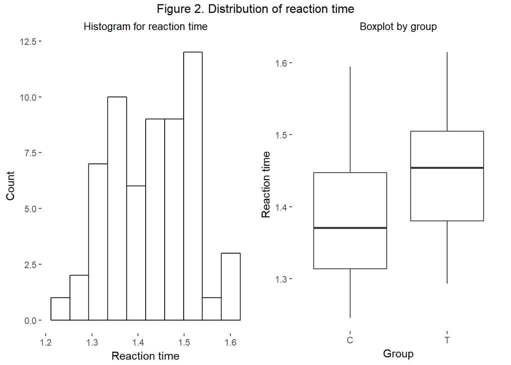

```r
p1<- ggplot(data=reaction.time, aes(time)) +
         geom_histogram(bins=10,color="black", fill="white") +
         xlab("Reaction time") + ylab("Count") +
        theme(panel.background = element_blank(),plot.title = element_text(size=10, hjust = 0.5)) +
        ggtitle("Histogram for reaction time")
p2<- ggplot(data=reaction.time, aes(x = control, y = time)) +
        geom_boxplot(alpha=0.7) + xlab("Group") + ylab("Reaction time") +
        theme(panel.background = element_blank(),plot.title = element_text(size=10, hjust = 0.5)) +
        ggtitle("Boxplot by group")
grid.arrange(p1, p2, ncol=2, top="Figure 2. Distribution of reaction time")
```

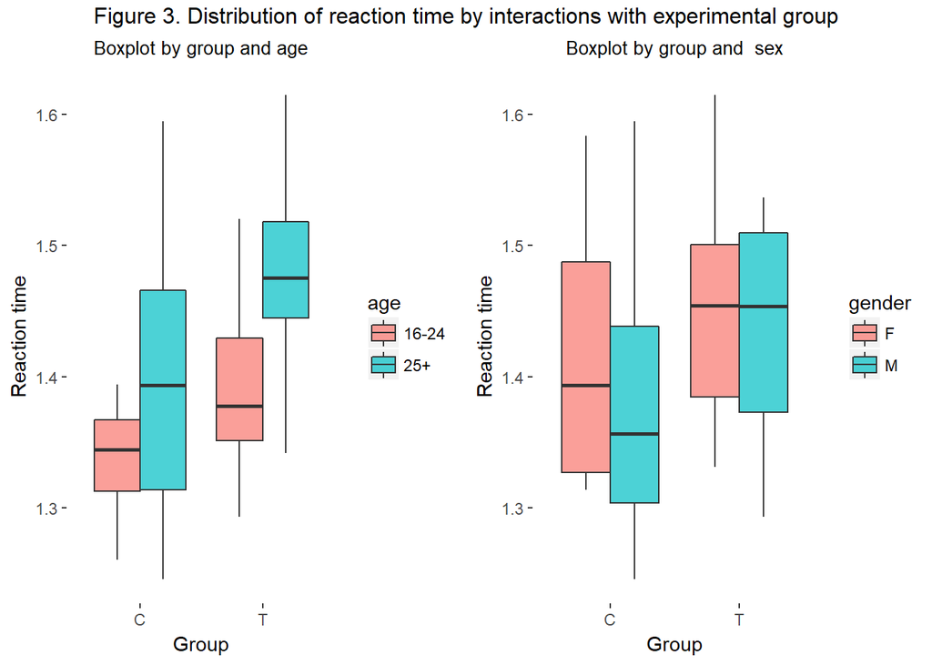

```r
p1<- ggplot(data=reaction.time, aes(x = control, y = time, fill = age)) +
        geom_boxplot(alpha=0.7) + xlab("Group") + ylab("Reaction time") +
        theme(panel.background = element_blank(),plot.title = element_text(size=10, hjust = 0.5)) +
        ggtitle("Boxplot by group and age")
p2<-ggplot(data=reaction.time, aes(x = control, y = time, fill = gender)) +
        geom_boxplot(alpha=0.7) + xlab("Group") + ylab("Reaction time") +
        theme(panel.background = element_blank(),plot.title = element_text(size=10, hjust = 0.5)) +
        ggtitle("Boxplot by group and  sex")
grid.arrange(p1, p2, ncol=2, top="Figure 3. Distribution of reaction time by interactions with experimental group")
```

```r
#Full model: Model with interactions
model1<- lm(time ~ control + age + gender + control*age + control*gender,
            data=reaction.time)

#Model without interactions
model2<- lm(time ~ control + age + gender ,
            data=reaction.time)
anova(model1, model2)
```

```
## Analysis of Variance Table
##
## Model 1: time ~ control + age + gender + control * age + control * gender
## Model 2: time ~ control + age + gender
##   Res.Df     RSS Df  Sum of Sq      F Pr(>F)
## 1     54 0.31644
## 2     56 0.31944 -2 -0.0029923 0.2553 0.7756
```

```r
#Final model
model3<- lm(time ~ control + age, data=reaction.time)
summary(model3)
```

```
##
## Call:
## lm(formula = time ~ control + age, data = reaction.time)
##
## Residuals:
##       Min        1Q    Median        3Q       Max
## -0.160301 -0.041801 -0.006049  0.043151  0.189103
##
## Coefficients:
##             Estimate Std. Error t value Pr(>|t|)
## (Intercept)  1.32487    0.02389  55.462  < 2e-16 ***
## controlT     0.07214    0.02111   3.417 0.001175 **
## age25+       0.08093    0.02111   3.833 0.000318 ***
## ---
## Signif. codes:  0 '***' 0.001 '**' 0.01 '*' 0.05 '.' 0.1 ' ' 1
##
## Residual standard error: 0.07554 on 57 degrees of freedom
## Multiple R-squared:  0.2785, Adjusted R-squared:  0.2532
## F-statistic:    11 on 2 and 57 DF,  p-value: 9.099e-05
```

```r
confint(model3)
```

```
##                  2.5 %    97.5 %
## (Intercept) 1.27703623 1.3727063
## controlT    0.02986224 0.1144234
## age25+      0.03864690 0.1232081
```

The dataset has 60 subjects, 40 in the experimental group and 20 in the control group. Fifty percent of the subjects were women, and the majority were older than 25 years (Figure 1). The dataset has four variables; Table 1 shows the raw data.

The overall average reaction time was 1.427 seconds (min=1.245, max=1.615). Figure 2 shows the boxplot by experimental group. We can see that the group that used cell phones while driving seems to have a higher reaction time as compared with the control group.

Figure 3 shows the reaction time by experimental group but this time independently by age and sex groups. There seems to be a differential behavior according to age, indicating a possible interaction between the experimental group and the age of the subject that affects the reaction time.

A multiple linear regression was performed to assess the effect of using cellphones while driving, adjusting for age and sex. Using cellphones showed an increment of the reaction time to an external event of 0.07 seconds (95% CI: 0.03, 0.11) after adjusting for age.